# BinningPlotting

Zaki Fadlullah

4 April 2016

## Drawing a 5’ to 3’ transcript plot

Often in RNA-seq data we would be interested to examine if there are any bias in the coverage across a transcript.

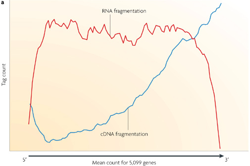

This R script shows hows how to draw such a plot and examine if such bias is present in our datasets.

```r
# Generate example coverage data for gene1 (g1)
g1 <- round(
  c(rnorm(866, mean=100),
    rnorm(11, mean=70),
    rnorm(30, mean=10),
    rnorm(7, mean=45),
    rnorm(30, mean=0, sd=0),
    rnorm(56, mean=5)))

length(g1)
```

```
## [1] 1000
```

The coverage data has 1000 values, but for plotting puropses we would not draw a plot of all 1000 base pair. Instead we would like to *bin* the value into 100 sections. The example below illustrates the point.

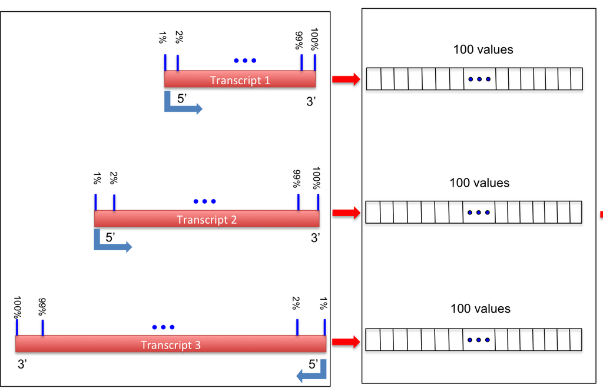

`g1` has 1000 data points and we now would like to divide the data into 100 bins. So how do we achive a bin something like below?

1. 1-10
2. 11-20
3. 21-30
4. 31-40
5. …
6. …
7. 971-980
8. 981-990
9. 991-1000

```r
# Lets use a script to do the binning process
# We use the library binr
# Bining the coverage into 100 bins
library(binr)
binfunc <- bins(1:length(g1), target.bins = 100, max.breaks = 100)
```

Lets examine the output of binr function, especially from *binct* object

```r
binlength <- as.numeric(binfunc$binct)
length(binlength) # Generates 100 bins
```

```
## [1] 100
```

```r
head(binfunc$binct) # Each individual bin contains 10 values
```

```
##  [1, 10] [11, 20] [21, 30] [31, 40] [41, 50] [51, 60]
##       10       10       10       10       10       10
```

```r
tail(binfunc$binct)
```

```
##  [941, 950]  [951, 960]  [961, 970]  [971, 980]  [981, 990] [991, 1000]
##          10          10          10          10          10          10
```

The *binct* object generates 100 bins as specified by the *target.bins* parameter and for each bin, it contains 10 data points. Now, lets assign the orignal coverage values to thier corresponding bins, for example ;

```r
g1[1:10]  # Belongs to bin 1
```

```
##  [1] 100  99  99 100 101 101 101 101 100 101
```

```r
g1[11:20] # Belongs to bin 2
```

```
##  [1] 101  99 101 101  99 101 100 100 101 100
```

```r
g1[21:30] # Belongs to bin 3
```

```
##  [1] 100 100 100  99 100 100  98 103 100 101
```

```r
# and so forth
```

Individualy we would do something like this ;

```r
bin1 <- rep("bin1", each=binlength[1])
bin2 <- rep("bin2", each=binlength[1])
```

```r
# Lets do it in a loop
# Create a category of the bin
binlist <- list()
for (i in seq_along(binlength)){
  binlist[[i]] <-  rep(i, each=binlength[i])
}
bincateg <- unlist(binlist)
```

Lets combine the orignal `g1` coverage data and the bin category into a data.frame

```r
# Data frame containing the coverage and the bin it belongs to
df_cov <- data.frame(value = g1,
                     bin = bincateg)
```

Lets get the mean coverage for each bin

```r
# Get the mean of each bin
library(dplyr)
df_bin <- as.data.frame(group_by(df_cov, bin) %>%
                          summarise(mean_cov = mean(value)))
```

Finally draw the plot with ggplot2

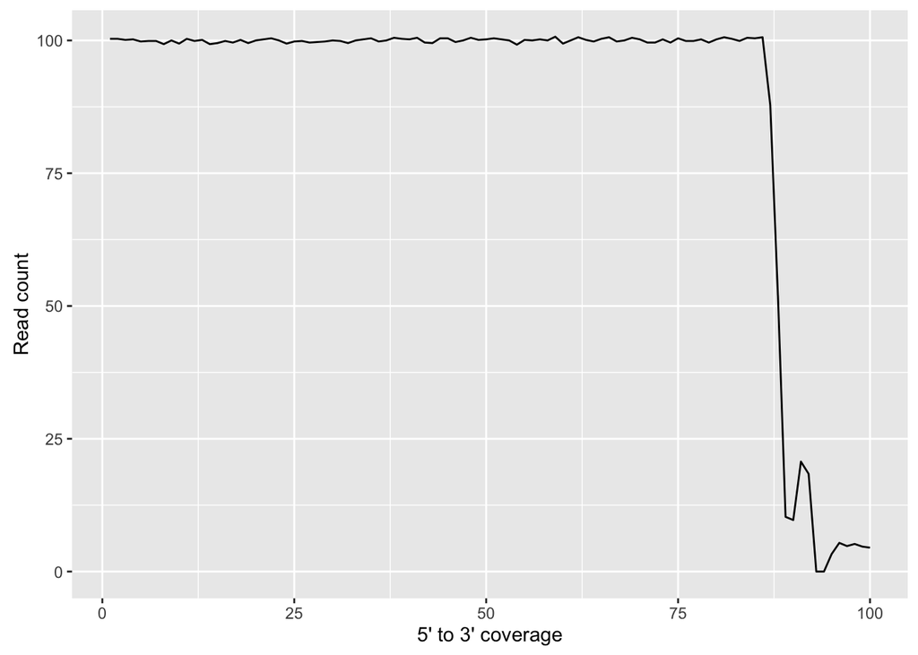

```r
library(ggplot2)
ggplot(df_bin, aes(x=bin, y=mean_cov)) +
  geom_line() +
  ylab("Read count") +
  xlab("5' to 3' coverage")
```